# Hito 2

**Nombres:** Gonzalo Sobarzo, Hernán Ulloa, Alexander Reisenegger, Ignacio Huenchumil.

**Fecha:** Noviembre 2022

**Grupo:** 11

**Curso:** CC5205

**Cuerpo docente:** Andres Abeliuk, Hernán Sarmiento, Cinthia Sánchez, Jorge Ortiz

# Introducción

Como equipo buscamos una base de datos de música para así llevar a cabo un estudio de datos para poder predecir (y corroborar) distintos comportamientos de los consumidores de música, como por ejemplo, buscar potenciales hits sabiendo la trayectoria del artista o tal vez un posible remix al ver la popularidad de la canción original de modo que se estudiaran distintas influencia de los atributos de las canciones en su éxito.

Nuestra base de datos consta de distintos premios y certificaciones para canciones, albumes, artistas y a su vez cuanto tiempo se mantuvo popular, de modo que solo se muestran canciones que sean éxitos del momento tanto en spotify como en la lista de billboard, esto sera útil para poder predecir distintos atributos de una canción o artista y así enfocar nuestro proyecto al análisis de tendecias musicales.

# Exploración de datos

El dataset consiste de 8 tablas (fuente del dataset:https://www.kaggle.com/datasets/danield2255/data-on-songs-from-billboard-19992019), una que contiene datos de las canciones que aparecen en la lista billboard 100 cada semana desde 1999 hasta 2019, incluyendo datos como el título, los artistas, los géneros de la cancion, artistas invitados y cuántas semanas ha pasado en el top hasta la fecha, y tabién una tabla que contiene datos de cada artista que ha aparecido en esa lista en dicho período de tiempo. También incluye 2 listas de los premios Grammy en el mismo intervalo de tiempo, una sobre canciones y una sobre los álbumes. Además una tabla de singles y una de álbumes según su certificación RIAA, también en el mismo período (certifica cuántas copias vendieron, por ejemplo certificación diamante, platino, multi platino, oro, diamante varias veces, entre otros). Por último hay 2 tablas de las canciones más populares de spotify desde 2016 hasta 2019, también semanales. Una tiene los datos generales del top 200 semanal como la cantidad de reproducciones y el nombre entre otros, y la otra tiene atributos para cada canción como por ejemplo energía, si está en modo mayor o menor, bailabilidad, etc.

Hay múltiples dudas que se puede plantear al respecto, por ejemplo la canción Radioactive de Imagine Dragons pasó casi 2 años en el Billboard 100, y sería interesante analizar por qué una canción mantiene su popularidad, mientras otras sólo se quedan en la fama por un corto período.

```python
import pandas as pd
import matplotlib.pyplot as plt
import seaborn as sns
import numpy as np
```

```python
artistDf = pd.read_csv('data/artistDf.csv')
spotifyWeeklyTop = pd.read_csv('data/spotifyWeeklyTop200Streams.csv')
songAttributes = pd.read_csv('data/songAttributes_1999-2019.csv')
grammySongs = pd.read_csv('data/grammySongs_1999-2019.csv', sep = ';')
billboardHot100 = pd.read_csv('data/billboardHot100_1999-2019.csv')
```

En la siguiente tabla se ve que Imagine Dragons Paso 87 semanas en el Chart:

```python
songs = billboardHot100.drop_duplicates(subset = ['Artists', 'Name'])
songs.sort_values(by = ['Weeks.on.chart'], ascending = False).head(2)
```

|  | Unnamed: 0 | Artists | Name | Weekly.rank | Peak.position | Weeks.on.chart | Week | Date | Genre | Writing.Credits | Lyrics | Features |
| --- | --- | --- | --- | --- | --- | --- | --- | --- | --- | --- | --- | --- |
| 25705 | 25706 | Imagine Dragons | Radioactive | 49 | 3.0 | 87.0 | 2014-05-09 | February 14, 2012 | Adult Alternative,Dubstep,Alternative Pop,Alte... | Imagine dragons, Daniel platzman, Wayne sermon... | Radioactive \nWhoah-oh\nWhoah-oh\nWhoah-oh\nWh... | NaN |
| 26334 | 26335 | AWOLNATION | Sail | 45 | 17.0 | 79.0 | 2014-03-21 | November 8, 2010 | Electro-Pop,Pop-Rock,Alternative Rock,Industri... | Aaron bruno | Sail \nSail!\nThis is how I show my love\nI ma... | NaN |

En esta tabla se puede ver una descripción de cada artista

```python
print(artistDf.shape)#dimensión de la tabla de Artists
artistDf.head()
```

```
(1035, 8)
```

|  | X | Artist | Followers | Genres | NumAlbums | YearFirstAlbum | Gender | Group.Solo |
| --- | --- | --- | --- | --- | --- | --- | --- | --- |
| 0 | 0 | Ed Sheeran | 52698756 | pop,uk pop | 8 | 2011 | M | Solo |
| 1 | 1 | Justin Bieber | 30711450 | canadian pop,dance pop,pop,post-teen pop | 10 | 2009 | M | Solo |
| 2 | 2 | Jonas Brothers | 3069527 | boy band,dance pop,pop,post-teen pop | 10 | 2006 | M | Group |
| 3 | 3 | Drake | 41420478 | canadian hip hop,canadian pop,hip hop,pop rap,... | 11 | 2010 | M | Solo |
| 4 | 4 | Chris Brown | 9676862 | dance pop,pop,pop rap,r&b,rap | 6 | 2005 | M | Solo |

Tabla de datos con el top 5 de spotify la semana del 20 de julio de 2018

```python
print(spotifyWeeklyTop.shape) #dimensión de la tabla de canciones semanales en spotify.
spotifyWeeklyTop.head()
```

```
(26395, 6)
```

|  | Unnamed: 0 | Name | Artist | Features | Streams | Week |
| --- | --- | --- | --- | --- | --- | --- |
| 0 | 0 | In My Feelings | Drake | NaN | 30747676 | 2018-07-20 |
| 1 | 1 | Lucid Dreams | Juice WRLD | NaN | 12930705 | 2018-07-20 |
| 2 | 2 | Nonstop | Drake | NaN | 12312859 | 2018-07-20 |
| 3 | 3 | God is a woman | Ariana Grande | NaN | 10771324 | 2018-07-20 |
| 4 | 4 | SAD! | XXXTENTACION | NaN | 10503061 | 2018-07-20 |

```python
print(billboardHot100.shape)#dimensión de la tabla de las canciones en el billboard.
billboardHot100.head(2)
```

```
(97225, 12)
```

|  | Unnamed: 0 | Artists | Name | Weekly.rank | Peak.position | Weeks.on.chart | Week | Date | Genre | Writing.Credits | Lyrics | Features |
| --- | --- | --- | --- | --- | --- | --- | --- | --- | --- | --- | --- | --- |
| 0 | 1 | Lil Nas, | Old Town Road | 1 | 1.0 | 7.0 | 2019-07-06 | April 5, 2019 | Country,Atlanta,Alternative Country,Hip-Hop,Tr... | Jozzy, Atticus ross, Trent reznor, Billy ray c... | Old Town Road Remix \nOh, oh-oh\nOh\nYeah, I'm... | Billy Ray Cyrus |
| 1 | 2 | Shawn Mendes, Camila Cabello | Senorita | 2 | NaN | NaN | 2019-07-06 | June 21, 2019 | Pop | Cashmere cat, Jack patterson, Charli xcx, Benn... | Senorita \nI love it when you call me senorita... | NaN |

```python
dicc = {}
i = 0
for row, col in songs.iterrows():
    aux = col['Genre'].split(',')
    for k in aux:
        if k in aux:
            dicc[k] = dicc.get(k,0) + 1
        i+=1
```

```python
gen = pd.DataFrame([[key, dicc[key]] for key in dicc.keys()], columns=['Genre', 'Frequency'])
gen1_5 = gen.sort_values(by = ['Frequency'], ascending=False)
```

```python
gen1_5 = gen.sort_values(by = ['Frequency'], ascending=False)
gen1_5.shape
```

```
(334, 2)
```

```python
gen2 = gen1_5.head(10)
gen2
```

|  | Genre | Frequency |
| --- | --- | --- |
| 9 | Pop | 2994 |
| 8 | Rap | 2465 |
| 46 | Rock | 1538 |
| 30 | R&;B | 1335 |
| 0 | Country | 1255 |
| 4 | Trap | 563 |
| 24 | Pop-Rock | 428 |
| 41 | Alternative Rock | 364 |
| 33 | Soundtrack | 357 |
| 20 | Canada | 327 |

En este gráfico de tablas se pueden ver los géneros mas recurrentes en el billboard top 100:

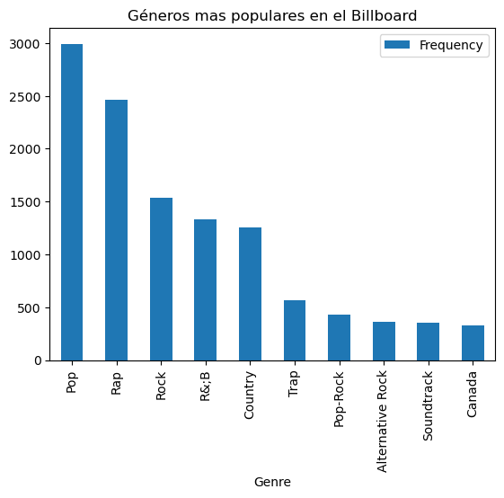

```python
ax = gen2.plot.bar(x='Genre', y = 'Frequency', stacked=True, title = "Géneros mas populares en el Billboard")
```

En esta tabla se pueden ver los premios grammy del 2018:

```python
print(grammySongs.shape)#dimensión de la tabla de canciones ganadora de los grammy's.
grammySongs.head()
```

```
(428, 7)
```

|  | Column1 | X | GrammyAward | GrammyYear | Genre | Name | Artist |
| --- | --- | --- | --- | --- | --- | --- | --- |
| 0 | 1 | 0 | Record Of The Year | 2018 | General | this is America | Childish Gambino |
| 1 | 2 | 1 | Song Of The Year | 2018 | General | this is America | Childish Gambino |
| 2 | 3 | 2 | Best Pop Solo Performance | 2018 | Pop | Joanne (where Do you Think You're Goin'?) | Lady Gaga |
| 3 | 4 | 3 | Best Pop Duo/Group Performance | 2018 | Pop | Shallow | Lady Gaga & Bradley Cooper |
| 4 | 5 | 4 | Best Dance Recording | 2018 | Dance/Electronic Music | Electricity | Silk City & Dua Lipa Featuring Diplo & Mark Ro... |

En esta tabla se muestran los artistas con mayor número de seguidores en spotify:

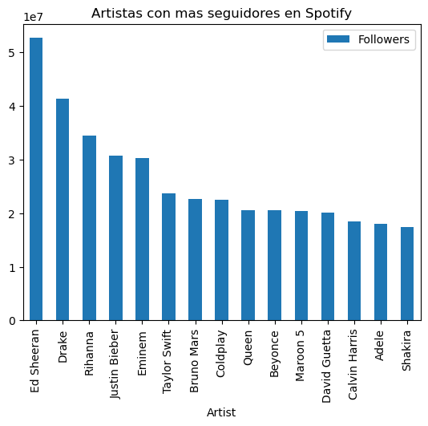

```python
artist_p = artistDf.sort_values(by = ['Followers'], ascending=False)
artist_p = artist_p.head(17)
artist_p = artist_p.drop([769, 828]) #elimina play y cold, ya que eran versiones repetidas de coldplay
ax = artist_p.plot.bar(x= 'Artist', y = 'Followers', stacked= True, title = "Artistas con mas seguidores en Spotify")
```

La siguiente matriz de correlación muestra como se comparan las variables de los artistas en spotify:

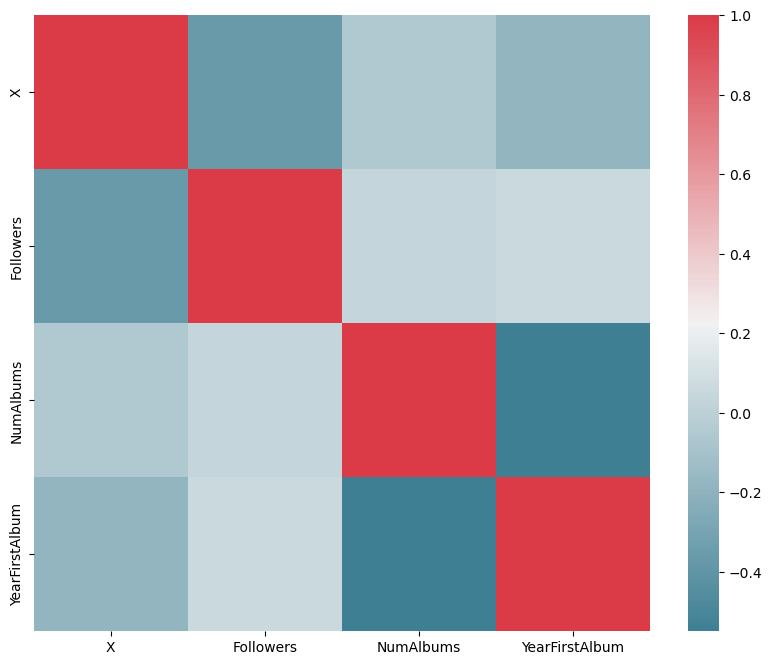

```python
f, ax = plt.subplots(figsize=(10, 8))
corr = artistDf.corr()
sns.heatmap(corr, mask=np.zeros_like(corr, dtype=bool), cmap=sns.diverging_palette(220, 10, as_cmap=True),
            square=True, ax=ax)
```

En el siguiente gráfico se observa que el artista que tiene más grammy's por canciones es Adele y la banda con más premios es U2:

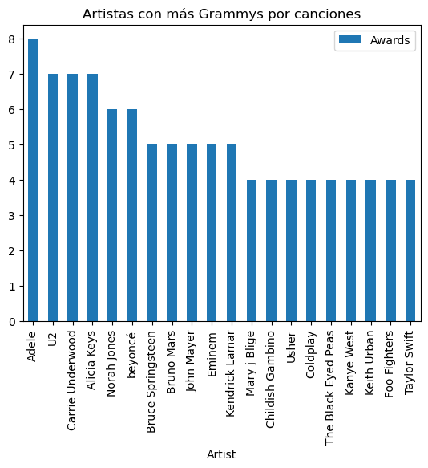

```python
winners = grammySongs.loc[:, ['Artist']]
gen3 = winners.groupby(winners.columns.tolist(),as_index=False).size().rename(columns={'size':'Awards'})
gen4 = gen3.sort_values(by = ['Awards'], ascending=False).head(20)
grs = gen4.plot.bar(x= 'Artist', y = 'Awards', stacked= True, title = 'Artistas con más Grammys por canciones')
```

El siguiente diagrama de cajas representa la distribución de los atributos, filtrados por las canciones que aparecen en la tabla de billboard 100:

```
(3193, 28)
```

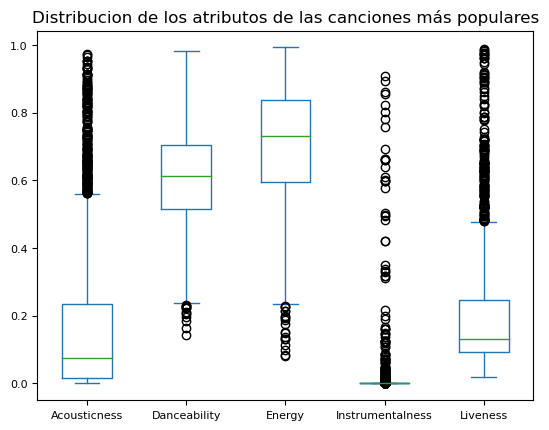

```python
songAttributes1 = songAttributes.rename(columns = {"Artist" : "Artists"})
songAttributes1.head()
sa = (
    songAttributes1.merge(billboardHot100,
              on=['Name', 'Artists'],
              how='left',
              indicator=True)
    .query('_merge == "both"')
    .drop(columns='_merge')
)
sa = sa.drop_duplicates(subset = ["Name", "Artists"])
print(sa.shape)
sa.iloc[:,[1, 4, 6, 8, 9]].plot.box(stacked=True, fontsize = 8, title = "Distribucion de los atributos de las canciones más populares")
```

Tabla de los atributos de canciones que estuvieron alguna vez en el Billboard:

```python
sa.head(2)
```

|  | Unnamed: 0_x | Acousticness | Album | Artists | Danceability | Duration | Energy | Explicit | Instrumentalness | Liveness | ... | Unnamed: 0_y | Weekly.rank | Peak.position | Weeks.on.chart | Week | Date | Genre | Writing.Credits | Lyrics | Features |
| --- | --- | --- | --- | --- | --- | --- | --- | --- | --- | --- | --- | --- | --- | --- | --- | --- | --- | --- | --- | --- | --- |
| 59 | 59 | 0.000877 | Dosage | Collective Soul | 0.547 | 173267 | 0.902 | False | 0.000563 | 0.0839 | ... | 97222.0 | 96.0 | 73.0 | 20.0 | 1999-07-12 | NaN | Hockey,Gaming,Soundtrack,Rock | Collective soul | Heavy \nComplicate this world you wrapped for ... | NaN |
| 185 | 33 | 0.587000 | Live At Open Air Gampel (2004) | Everlast | 0.316 | 396896 | 0.634 | False | 0.000019 | 0.9070 | ... | 96997.0 | 47.0 | 13.0 | 33.0 | 1999-07-26 | NaN | Rap,Rock | Everlast | What It's Like \nWe've all seen the man at the... | NaN |

2 rows × 28 columns

A su vez una tabla con los valores independientes

```python
print(songAttributes.shape) #dimensión de la tabla song attributes.
songAttributes.head(2)
```

```
(154931, 18)
```

|  | Unnamed: 0 | Acousticness | Album | Artist | Danceability | Duration | Energy | Explicit | Instrumentalness | Liveness | Loudness | Mode | Name | Popularity | Speechiness | Tempo | TimeSignature | Valence |
| --- | --- | --- | --- | --- | --- | --- | --- | --- | --- | --- | --- | --- | --- | --- | --- | --- | --- | --- |
| 0 | 0 | 0.000728 | Collective Soul (Deluxe Version) | Collective Soul | 0.520 | 234947 | 0.904 | False | 0.010300 | 0.0634 | -5.030 | 1 | Welcome All Again | 35 | 0.0309 | 106.022 | 4 | 0.365 |
| 1 | 1 | 0.018200 | Collective Soul (Deluxe Version) | Collective Soul | 0.581 | 239573 | 0.709 | False | 0.000664 | 0.1740 | -4.909 | 1 | Fuzzy | 31 | 0.0282 | 120.027 | 4 | 0.408 |

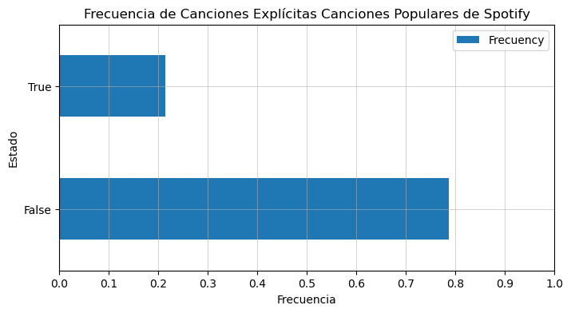

```python
explicit = songAttributes.Explicit.value_counts(normalize=True)
df2 = pd.DataFrame([
                    ["False",explicit[0]],
                    ["True",explicit[1]]
                    ],
                    columns=["State","Frecuency"])

ax  = df2.plot.barh(x = "State", y = "Frecuency", xticks = [k/10 for k in list(range(11))], figsize = (8,4))
ax.set(xlabel = "Frecuencia", ylabel = "Estado", title = "Frecuencia de Canciones Explícitas Canciones Populares de Spotify")
ax.grid(linestyle='-', linewidth=0.4)
plt.show()
```

# Preguntas y problemas

Preguntas y problemas Despues de haber analizando y planteado las tablas con sus respectivos datos sabemos que todas las tablas poseen una medida de popularidad, alcance o ventas, que miden la influencia de la canción artista y/o album, al mismo tiempo se puede ver que estos rankings son distintos ya que spotify tiene una base de datos distinta a las demas tablas (Billboard's, Grammy's) Por lo cual podemos manejarnos entre las tablas midiendo la popularidad con las siguientes preguntas:

- ¿Que hace que ciertos géneros musicales se mantengan mas tiempo con popularidad?

Hay Géneros que se mantienen atemporales y siempre figuran en los charts en el transcurso de los 20 años que se registran como es el caso del POP que es el que aparece más veces en la base de datos.

- ¿Qué genero musical llegará al top 1 del Billboard la semana del 13 de Julio del 2019?

El objetivo es estudiar basado en los top anteriores ver si hay algún patrón que permita predecir el género musical de la próxima canción en llegar al primer puesto.

- ¿Qué conjunto de atributos extraídos de las canciones, representa de mejor manera las diferencias entre géneros?

El objetivo de esta pregunta es ver como las canciones pertenecientes a ciertos géneros se diferencian de otras de otros géneros musicales.

# Pregunta 1

> Planteamos la pregunta de modo que se puedan agrupar distintas características de los géneros mediante clustering para poder asi encontrar patrones que poseen los géneros con mayor cantidad de apariciones en el chart del billboard y los patrones que poseen los géneros que no perduran en este último, para asi comparar estos atributos y determinar si existen ciertos patrones convincentes para determinar canciones que perduren en el billboard y/o tengan un mayor número de apariciones de modo que se agruparan las tablas de los billboardhot100, songatributes, grammyawards y ArtistDF para tener distintas agrupaciones posibles para analizar der forma más efectiva los datasets.

```python
# J_table = billboardHot100.drop_duplicates(subset = ['Name'])
# JT = (
#     songAttributes.merge(J_table,
#               on=['Name', 'Artist'],
#               how='left',
#               indicator=True)
#     .query('_merge == "both"')
#     .drop(columns='_merge')
# )
# a=JT.drop(columns=("Album"))
# b=a.drop(columns=("Unnamed: 0_x"))
# c=b.drop(columns=('Unnamed: 0_y'))
# d=c.drop(columns=('Lyrics'))
# e=d.drop(columns=('Writing.Credits'))
# f=e.drop(columns=('Features'))



# #JT_2 = (
# #    artistDf.merge(f,
#  #             on=['Followers', 'Artist'],
#   #            how='left',
#    #           indicator=True)
#     #.query('_merge == "both"')
#     #.drop(columns='_merge')
# #)
# #g=f.drop(columns=('Features'))
# #h=g.drop(columns=('Features'))
# #i=h.drop(columns=('Features'))
# f.sort_values(by = ['Weeks.on.chart'], ascending = False).columns
```

# Pregunta 2

Inicialmente se crea una tabla que contiene los géneros de todas las canciones del billboard acotados a una lista más corta, pero que los representa a todos. Ésto se hace porque hay en total más de 300 géneros y cada canción tiene de 1 a 10.

```python
study_table = billboardHot100
genres = pd.DataFrame(study_table["Genre"])
genres2 = genres.dropna(axis = 1)
genres2.columns = ['gen']
normal_genres = [ 'Rock', 'Country', 'Alternative', 'Country', 'Rap', 'Pop', 'R&;B']
for i, row in genres.iterrows():
    for j in row:
        for word in normal_genres:
            word2 = word
            word2.lower()
            if j.find(word)!=-1 or j.find(word2)!=-1:
                genres2.at[i, 'gen'] = word
                break
        break
genres2
```

|  | gen |
| --- | --- |
| 0 | Country |
| 1 | Pop |
| 2 | Alternative |
| 3 | Pop |
| 4 | Pop |
| ... | ... |
| 97220 | Pop |
| 97221 | Rock |
| 97222 | Country |
| 97223 | Rap |
| 97224 | Rock |

97225 rows × 1 columns

```python
genres3 = genres2.groupby(genres2.columns.tolist(),as_index=False).size().rename(columns={'size':'count'})
genres3 = genres3.sort_values(by = "count", ascending = False)
genres3.head(50) #para analizar los datos de genres2
```

|  | gen | count |
| --- | --- | --- |
| 4 | Rap | 28866 |
| 5 | Rock | 26751 |
| 2 | Pop | 23492 |
| 1 | Country | 12106 |
| 3 | R&;B | 4069 |
| 0 | Alternative | 1941 |

Aquí se genera una tabla con cada semana, y los datos que aparecen en el billboard de todas las canciones de la semana anterior. Cada fila de la tabla representa una semana con las canciones correspondientes. Tiene también una columna que representa el género del top 1 de la semana actual, lo que servirá de clase para realizar la predicción.

```python
#7-06-2019 top100genero, top100nombre, top100artista..., top99genero...  top1genero (no anhadir nada mas del top1)
billboardColumns = ['Artists', 'Name', 'Weeks.on.chart', 'Date' ,'Genre']
columnas = ['semana', 'top1prediccion']
for i in range(1, 101):
    for name in billboardColumns:
        string ='top' + str(i) + name
        columnas.append(string)
weeks = pd.DataFrame(billboardHot100['Week'])
weeks = weeks.drop_duplicates( subset = ["Week"], ignore_index = True)
weeks = weeks['Week']

tablaPrediccion = pd.DataFrame(columns = columnas)
print(weeks.shape)
print(tablaPrediccion.shape)
for i in range(len(weeks)-1):
    currentWeek = weeks[i]
    data = [currentWeek]
    oldWeek = weeks[i+1]
    for  row in billboardHot100.itertuples():
        j = row.Index
        if(row.Week == currentWeek and row._4==1):
            data.append(genres2.at[j, 'gen'])
        if(row.Week == oldWeek):
            for word in billboardColumns:
                if word!='Genre':
                    data.append(billboardHot100.at[j, word])
                else:
                    data.append(genres2.at[j, 'gen'])
    while(len(data) < 502):
        data.append("None")
    tablaPrediccion.loc[len(tablaPrediccion)] = data
```

```
(1043,)
(0, 502)
```

```python
#limpieza de datos de la tabla generada, ya que en la tabla original faltan algunos top 1
genresmaximos = genres3['gen'].to_numpy()
tablaPrediccion2 = tablaPrediccion[tablaPrediccion.top1prediccion.isin(genresmaximos)]
```

Luego se vectorizan los datos de la tabla para poder aplicarle un clasificador que prediga la clase (género) del top 1 utilizando los datos de la semana anterior.

```python
import requests
import re
import string
from sklearn.feature_extraction.text import CountVectorizer
from sklearn.preprocessing import OneHotEncoder

stopwords_list = 'english'

def remove_vowels_accents(text):
    return (
        text.replace("á", "a")
        .replace("é", "e")
        .replace("í", "i")
        .replace("ó", "o")
        .replace("ú", "u")
        .replace("ü", "u")
    )

def remove_stopwords(text, stopwords_list):
    return " ".join(
        [word for word in str(text).split() if word not in stopwords_list]
    )

def reduce_spam(text):
    text = re.sub(r"(\w+)(\s+\1){2,}", r"\1", text)
    text = re.sub(r"(\w+\s+\w+)(\s+\1){2,}", r"\1", text)
    return text

def remove_unprintable_(text):
    printable = set(string.printable + "ñáéíóúü" + "ÑÁÉÍÓÚÜ")
    text = "".join(filter(lambda x: x in printable, text))
    return text

def remove_punctuation(text):
    pattern = re.compile(r"[^\w\sáéíóúüñÁÉÍÓÚÜÑ]")
    t = pattern.sub(r" ", text)
    return re.sub(" +", " ", t)

def preprocesar(text):
    text = text.lower()
    text = remove_unprintable_(text)
    text = remove_punctuation(text)
    text = reduce_spam(text)
    text = remove_stopwords(text, stopwords_list)
    text = remove_vowels_accents(text)
    return text.strip()

vectorizer = CountVectorizer(preprocessor=preprocesar, min_df=2)
tablaPrediccion3 = tablaPrediccion2.drop(columns = ["top1prediccion", "semana"])
vector = 0
for word in tablaPrediccion3.columns:
    if ("Weeks.on.chart" in word or "Date" in word):
        x=1
    else:
        if type(vector) == int:
            vector = vectorizer.fit_transform(tablaPrediccion3[word]).toarray()
            vector = pd.DataFrame(vector, columns=vectorizer.get_feature_names_out())
        else:
            vector2 = vectorizer.fit_transform(tablaPrediccion3[word]).toarray()
            vector2 = pd.DataFrame(vector2, columns=vectorizer.get_feature_names_out())
            pd.concat([vector, vector2], axis = 1)
```

```python
X = vector
y = tablaPrediccion2["top1prediccion"]
y2 = pd.DataFrame(y)

df_vectorizado = pd.concat([y, X], axis=1)
df_vectorizado.dropna(subset = "top1prediccion")[50:150]
```

|  | top1prediccion | 50 | adele | aguilera | aiken | akon | alicia | and | ariana | ashanti | ... | town | trainor | usher | wayne | weeknd | west | white | williams | wiz | yankee |
| --- | --- | --- | --- | --- | --- | --- | --- | --- | --- | --- | --- | --- | --- | --- | --- | --- | --- | --- | --- | --- | --- |
| 50 | Rap | 0.0 | 0.0 | 0.0 | 0.0 | 0.0 | 0.0 | 0.0 | 0.0 | 0.0 | ... | 0.0 | 0.0 | 0.0 | 0.0 | 0.0 | 0.0 | 0.0 | 0.0 | 0.0 | 0.0 |
| 51 | Rap | 0.0 | 0.0 | 0.0 | 0.0 | 0.0 | 0.0 | 0.0 | 0.0 | 0.0 | ... | 0.0 | 0.0 | 0.0 | 0.0 | 0.0 | 0.0 | 0.0 | 0.0 | 0.0 | 0.0 |
| 52 | Rap | 0.0 | 0.0 | 0.0 | 0.0 | 0.0 | 0.0 | 0.0 | 0.0 | 0.0 | ... | 0.0 | 0.0 | 0.0 | 0.0 | 0.0 | 0.0 | 0.0 | 0.0 | 0.0 | 0.0 |
| 53 | Alternative | 0.0 | 0.0 | 0.0 | 0.0 | 0.0 | 0.0 | 0.0 | 0.0 | 0.0 | ... | 0.0 | 0.0 | 0.0 | 0.0 | 0.0 | 0.0 | 0.0 | 0.0 | 0.0 | 0.0 |
| 54 | Rap | 0.0 | 0.0 | 0.0 | 0.0 | 0.0 | 0.0 | 0.0 | 0.0 | 0.0 | ... | 0.0 | 0.0 | 0.0 | 0.0 | 0.0 | 0.0 | 0.0 | 0.0 | 0.0 | 0.0 |
| ... | ... | ... | ... | ... | ... | ... | ... | ... | ... | ... | ... | ... | ... | ... | ... | ... | ... | ... | ... | ... | ... |
| 145 | Pop | 0.0 | 0.0 | 0.0 | 0.0 | 0.0 | 0.0 | 0.0 | 0.0 | 0.0 | ... | 0.0 | 0.0 | 0.0 | 0.0 | 0.0 | 0.0 | 0.0 | 0.0 | 0.0 | 0.0 |
| 146 | Pop | 0.0 | 0.0 | 0.0 | 0.0 | 0.0 | 0.0 | 0.0 | 0.0 | 0.0 | ... | 0.0 | 0.0 | 0.0 | 0.0 | 0.0 | 0.0 | 0.0 | 0.0 | 0.0 | 0.0 |
| 147 | Pop | 0.0 | 0.0 | 0.0 | 0.0 | 0.0 | 0.0 | 0.0 | 0.0 | 0.0 | ... | 0.0 | 0.0 | 0.0 | 0.0 | 0.0 | 0.0 | 0.0 | 0.0 | 0.0 | 0.0 |
| 148 | Pop | 0.0 | 0.0 | 0.0 | 0.0 | 0.0 | 0.0 | 0.0 | 0.0 | 0.0 | ... | 0.0 | 0.0 | 0.0 | 0.0 | 0.0 | 0.0 | 0.0 | 0.0 | 0.0 | 0.0 |
| 149 | Rap | 0.0 | 0.0 | 0.0 | 0.0 | 0.0 | 0.0 | 0.0 | 0.0 | 0.0 | ... | 0.0 | 0.0 | 0.0 | 0.0 | 0.0 | 0.0 | 0.0 | 0.0 | 0.0 | 0.0 |

100 rows × 160 columns

```python
test = y2.groupby(y2.columns.tolist(),as_index=False).size().rename(columns={'size':'count'})
test = test.sort_values(by = "count", ascending = False)
test.head() #para analizar los datos de la tabla
```

|  | top1prediccion | count |
| --- | --- | --- |
| 4 | Rap | 386 |
| 2 | Pop | 371 |
| 5 | Rock | 123 |
| 0 | Alternative | 66 |
| 3 | R&;B | 20 |

Finalmente se le aplica el clasificador

```python
from sklearn.tree import DecisionTreeClassifier
from sklearn.metrics import accuracy_score
from sklearn.metrics import classification_report
from sklearn.model_selection import train_test_split

clf = DecisionTreeClassifier(random_state = 2)
X_train, X_test, y_train, y_test = train_test_split(X, y, test_size=0.30, random_state=2, stratify=y)
clf.fit(X_train, y_train)
y_pred = clf.predict(X_test)
print("Accuracy:", accuracy_score(y_test, y_pred))
print(classification_report(y_test, y_pred))
```

```
Accuracy: 0.6779661016949152
              precision    recall  f1-score   support

 Alternative       0.79      0.75      0.77        20
     Country       1.00      0.80      0.89         5
         Pop       0.61      0.80      0.70       111
        R&;B       1.00      0.50      0.67         6
         Rap       0.73      0.62      0.67       116
        Rock       0.68      0.46      0.55        37

    accuracy                           0.68       295
   macro avg       0.80      0.66      0.71       295
weighted avg       0.69      0.68      0.67       295
```

Los resultados son aceptables, pero podrían ser mejores. Para el próximo hito se cambiará la forma en la que se realiza la vectorización, de manera que se utilizará OneHotEncoder para los nombres de artistas y los géneros, y se separarán los datos del top.

# Pregunta 3

> Como la tabla de 'songAttributes' no tiene el atributo de género musical de la canción, se utiliza la tabla de 'artistDf' que contienen informarción de los artistas incluyendo su género musical. la idea es generar cluster's que en teoría deberían agruparse según géneros musicales por lo primero se evaluará la pureza de estos, por lo que se usáran distintas formas de hacer cluster's, es decir, se usarán métodos como k-means, los dendogramas, etc. Si no se obtienen cluster's puros se procederá con subconjuntos de atributos para así encontrar donde más se diferencian los géneros musicales. Para facilitar el estudio de esto se tomarán los géneros musicales que aparecen primero en la tabla de 'artistDf' y posteriormente mediante clustering dar etiquetas más claras a cada canción.

## Data cleaning

```python
from sklearn.decomposition import PCA
from sklearn.cluster import KMeans
```

Se visualizan el contenido de las Dataframe que son relevantes para desarrollar esta pregunta.

```python
songAttributes.head(2)
```

|  | Unnamed: 0 | Acousticness | Album | Artist | Danceability | Duration | Energy | Explicit | Instrumentalness | Liveness | Loudness | Mode | Name | Popularity | Speechiness | Tempo | TimeSignature | Valence |
| --- | --- | --- | --- | --- | --- | --- | --- | --- | --- | --- | --- | --- | --- | --- | --- | --- | --- | --- |
| 0 | 0 | 0.000728 | Collective Soul (Deluxe Version) | Collective Soul | 0.520 | 234947 | 0.904 | False | 0.010300 | 0.0634 | -5.030 | 1 | Welcome All Again | 35 | 0.0309 | 106.022 | 4 | 0.365 |
| 1 | 1 | 0.018200 | Collective Soul (Deluxe Version) | Collective Soul | 0.581 | 239573 | 0.709 | False | 0.000664 | 0.1740 | -4.909 | 1 | Fuzzy | 31 | 0.0282 | 120.027 | 4 | 0.408 |

```python
artistDf.head(2)
```

|  | X | Artist | Followers | Genres | NumAlbums | YearFirstAlbum | Gender | Group.Solo |
| --- | --- | --- | --- | --- | --- | --- | --- | --- |
| 0 | 0 | Ed Sheeran | 52698756 | pop,uk pop | 8 | 2011 | M | Solo |
| 1 | 1 | Justin Bieber | 30711450 | canadian pop,dance pop,pop,post-teen pop | 10 | 2009 | M | Solo |

```python
data_cleaned = songAttributes.merge(artistDf.loc[:,['Artist', 'Genres']],
                                on = ['Artist'],
                                how = 'inner',
                                indicator = False)

data_cleaned = data_cleaned.drop(labels = ['Unnamed: 0'], axis = 1)
data_cleaned['Explicit'] = data_cleaned['Explicit'].astype(int)


idx = data_cleaned.columns.get_loc("Name")
columns = data_cleaned.columns.to_list()[idx:idx+1] + data_cleaned.columns.to_list()[1: idx] + data_cleaned.columns.to_list()[0:1] + data_cleaned.columns.to_list()[idx+1:] #webeo para cambiar el orden de columnas
data_cleaned = data_cleaned[columns]

data_cleaned_sample = data_cleaned.sample(n = 4000, replace = False, random_state= 27)
```

```python
data_cleaned_sample.head(2)
```

|  | Name | Album | Artist | Danceability | Duration | Energy | Explicit | Instrumentalness | Liveness | Loudness | Mode | Acousticness | Popularity | Speechiness | Tempo | TimeSignature | Valence | Genres |
| --- | --- | --- | --- | --- | --- | --- | --- | --- | --- | --- | --- | --- | --- | --- | --- | --- | --- | --- |
| 105914 | True Colors (Glee Cast Version) | Glee: The Music, The Complete Season One | Glee Cast | 0.611 | 214000 | 0.387 | 0 | 0.0 | 0.2130 | -7.949 | 1 | 0.1180 | 36 | 0.0242 | 85.978 | 4 | 0.335 | glee club,hollywood,pop,post-teen pop |
| 30003 | No Soy El Aire | Habítame Siempre (Bonus Tracks Version) | Thalia | 0.362 | 246413 | 0.596 | 0 | 0.0 | 0.0755 | -7.054 | 0 | 0.0369 | 41 | 0.0338 | 148.471 | 4 | 0.201 | dance pop,latin,latin pop,mexican pop,pop,trop... |

Se eliminan atributos de texto que no pueden ser utilizados en KMeans como el nombre del artista, el nombre del albúm y el nombre de la canción por ser datos en forma de texto (lo mismo se hizo para cada metodología de clustering):

```python
# se eliminan atributos de texto que no pueden ser utilizados en KMeans
data_k_means = data_cleaned_sample.drop(columns = ['Album','Artist', 'Name'])
data_k_means = data_k_means.drop(columns = ['Duration','Popularity','Tempo','TimeSignature','Genres'])
```

De esta forma se toma el conjunto `[Danceability, Energy, Explicit, Instrumentalness, Liveness, Loudness, Mode, Acousticness, Speechiness, Valence]` para hacer el clustering en K-means y el resto de los métodos, ya que se considera que cosas como Popularidad no son relevantes, ya que no aportan elementos musicales de las composiciones, se descartó Duración y Tempo ya que al no estar normalizados ocasionaría problemas para el desarrollo del clustering, también se saco 'Time Signature', ya que no se comprende bien lo que evalua o lo que se mide, ya que en el dataset original de kaggle no se encontró una explicación satisfactoria de este:

Quedando así la tabla para agrupar las canciones:

```python
data_k_means.head()
```

|  | Danceability | Energy | Explicit | Instrumentalness | Liveness | Loudness | Mode | Acousticness | Speechiness | Valence |
| --- | --- | --- | --- | --- | --- | --- | --- | --- | --- | --- |
| 105914 | 0.611 | 0.387 | 0 | 0.000000 | 0.2130 | -7.949 | 1 | 0.1180 | 0.0242 | 0.335 |
| 30003 | 0.362 | 0.596 | 0 | 0.000000 | 0.0755 | -7.054 | 0 | 0.0369 | 0.0338 | 0.201 |
| 36149 | 0.680 | 0.605 | 0 | 0.000094 | 0.3000 | -6.745 | 1 | 0.2630 | 0.0258 | 0.677 |
| 14723 | 0.732 | 0.572 | 0 | 0.000000 | 0.1250 | -7.426 | 1 | 0.3890 | 0.2950 | 0.816 |
| 76273 | 0.926 | 0.665 | 0 | 0.000000 | 0.0645 | -4.866 | 0 | 0.1060 | 0.2600 | 0.220 |

Se prodeció a reducir la dimensionalidad mediante PCA para poder gráficar los datos en un gráfico:

```python
pca = PCA(n_components=2).fit(data_k_means)
rates_pca = pca.transform(data_k_means)
rates_pca.shape
```

```
(4000, 2)
```

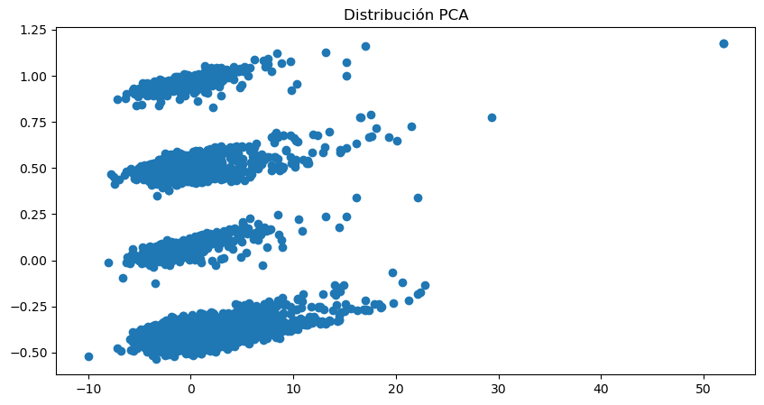

```python
fig, ax = plt.subplots(sharex=True, figsize = (10,5))
plt.scatter(rates_pca[:,0], rates_pca[:,1])
plt.title('Distribución PCA')
plt.show()
```

Método de la rodilla para obtener el número óptimo de cluster's, donde se opta por usar `k = 4` para k-means:

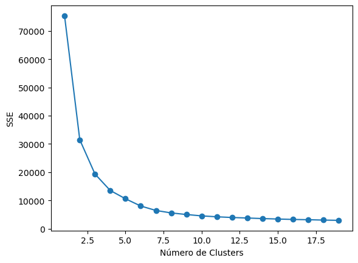

```python
SSE = []
numClusters = list(range(1, 20))
for k in numClusters:
    k_means = KMeans(n_clusters=k, n_init=20, max_iter= 300, random_state=1)
    k_means.fit(data_k_means)
    SSE.append(k_means.inertia_)

plt.plot(numClusters, SSE, marker="o")
plt.xlabel('Número de Clusters')
plt.ylabel('SSE')
plt.show()
```

```python
kmeans =  KMeans(n_clusters=4, n_init = 20, random_state=1)
kmeans.fit(data_k_means)
y_pred = kmeans.labels_
np.bincount(y_pred)
```

```
array([1380,  580, 1940,  100], dtype=int64)
```

## K-means:

Se procede a ejecutar k-means para poder agrupar en cluster's los datos:

```python
kmeans =  KMeans(n_clusters=4, n_init = 20, max_iter= 300 , random_state=1)
kmeans.fit(data_k_means)
y_pred = kmeans.labels_
np.bincount(y_pred)
```

```
array([1380,  580, 1940,  100], dtype=int64)
```

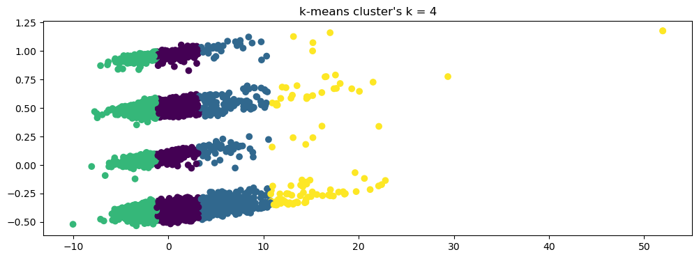

```python
fig, ax = plt.subplots(sharex=True, figsize = (12, 4))
plt.scatter(rates_pca[:, 0], rates_pca[:, 1], c= kmeans.labels_)
plt.title("k-means cluster's k = 4")
```

## Clustering Jerárquico

En esta sección se aplicaron los distintos métodos de clustering jerárquico menos Single que al no lograr un dendograma muy útil se decidió por descartarlo por temas de espacio del informe. A continuación se limpian los datos de la misma forma que en k-means:

```python
from scipy.cluster.hierarchy import dendrogram, linkage
from sklearn.cluster import AgglomerativeClustering
```

```python
names = data_cleaned_sample['Name']
Y = data_cleaned_sample['Genres']
X = data_cleaned_sample.drop(columns = ['Album','Artist', 'Name', 'Genres', 'Duration','Popularity','Tempo','TimeSignature'])
```

```python
X.head(2)
```

|  | Danceability | Energy | Explicit | Instrumentalness | Liveness | Loudness | Mode | Acousticness | Speechiness | Valence |
| --- | --- | --- | --- | --- | --- | --- | --- | --- | --- | --- |
| 105914 | 0.611 | 0.387 | 0 | 0.0 | 0.2130 | -7.949 | 1 | 0.1180 | 0.0242 | 0.335 |
| 30003 | 0.362 | 0.596 | 0 | 0.0 | 0.0755 | -7.054 | 0 | 0.0369 | 0.0338 | 0.201 |

### WARD

Procediendo con el método ward se opto por cortar en `x = 40`, ya que con eso se logra unos cluster's de tamaño más o menos uniforme:

```
[]
```

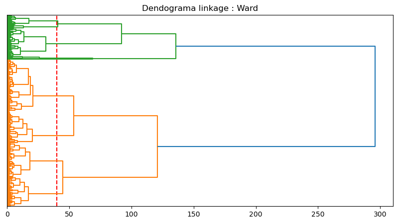

```python
fig, ax = plt.subplots(sharex=True, figsize = (10,5))
Z = linkage(X, method='ward', metric='euclidean') # distancia maxima entre putnos
plt.axvline(x= 40, color='r', linestyle='--')
dn = dendrogram(Z, labels = ['' for k in range(0,len(X))], orientation='right')
plt.title('Dendograma linkage : Ward')
plt.plot()
```

```python
distance = 40

ward_euclidean = AgglomerativeClustering(linkage='ward',
                                affinity='euclidean',
                                n_clusters=None,
                                distance_threshold=distance).fit(X)
```

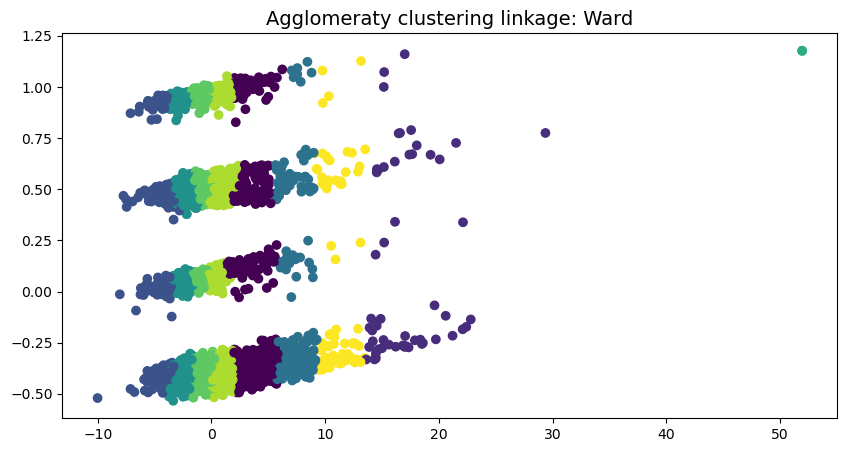

```
array([0, 1, 2, 3, 4, 5, 6, 7, 8], dtype=int64)
```

```python
fig, ax = plt.subplots(sharex=True, figsize = (10,5))
plt.scatter(rates_pca[:,0],rates_pca[:,1], c= ward_euclidean.labels_)
plt.title('Agglomeraty clustering linkage: Ward').set_fontsize(14)
plt.show()
np.unique(ward_euclidean.labels_)
```

### COMPLETE

Con complete se decidió por cortar en `x = 0.1`:

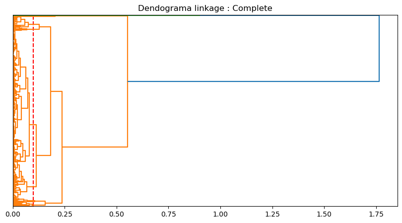

```python
fig, ax = plt.subplots(sharex=True, figsize = (10,5))
Z = linkage(X, method='complete', metric='cosine') # distancia maxima entre putnos
dn = dendrogram(Z, labels = None,orientation='right')
plt.axvline(x= 0.1, color='r', linestyle='--')
dn = dendrogram(Z, labels = ['' for k in range(0,len(X))], orientation='right')
plt.title('Dendograma linkage : Complete')
```

```python
distance = 0.1

complete_cosine = AgglomerativeClustering(linkage='complete',
                                affinity='cosine',
                                n_clusters=None,
                                distance_threshold= distance).fit(X)
```

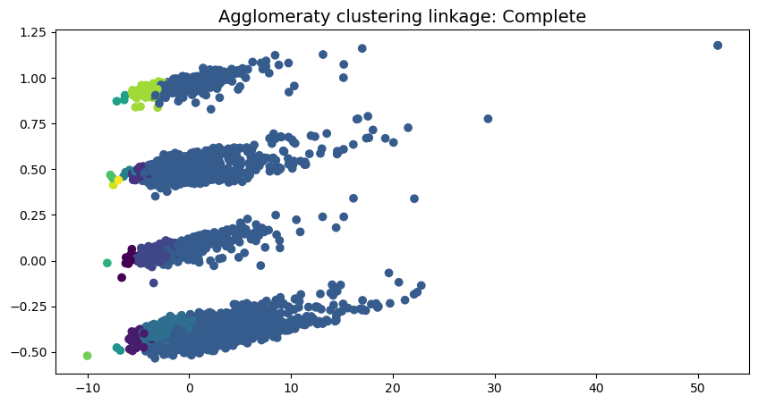

```
array([ 0,  1,  2,  3,  4,  5,  6,  7,  8,  9, 10, 11, 12, 13, 14],
      dtype=int64)
```

```python
fig, ax = plt.subplots(sharex=True, figsize = (10,5))
plt.scatter(rates_pca[:,0],rates_pca[:,1], c= complete_cosine.labels_)
plt.title('Agglomeraty clustering linkage: Complete').set_fontsize(14)
plt.show()
np.unique(complete_cosine.labels_)
```

### Average

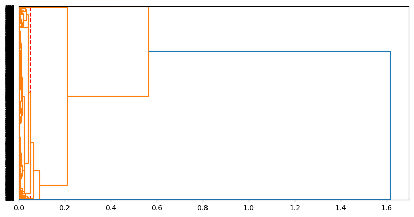

```python
fig, ax = plt.subplots(sharex=True, figsize = (10,5))
Z = linkage(X, method='average', metric='cosine')
plt.axvline(x= 0.05, color='r', linestyle='--')
dn = dendrogram(Z, labels= None,orientation='right')
```

```python
distance = 0.12
n_clusters = None

average_cosine = AgglomerativeClustering(linkage='average',
                                affinity='cosine',
                                n_clusters=n_clusters,
                                distance_threshold= distance).fit(X)
```

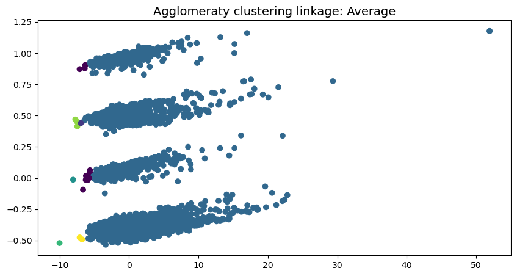

```
array([0, 1, 2, 3, 4, 5, 6], dtype=int64)
```

```python
fig, ax = plt.subplots(sharex=True, figsize = (10,5))
plt.scatter(rates_pca[:,0],rates_pca[:,1], c= average_cosine.labels_)
plt.title('Agglomeraty clustering linkage: Average').set_fontsize(14)
plt.show()
np.unique(average_cosine.labels_)
```

## DBSCAN

```python
from sklearn.cluster import DBSCAN
from sklearn.neighbors import NearestNeighbors
```

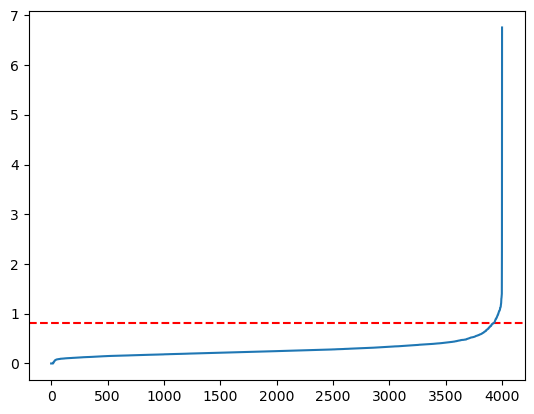

```python
N = 14
nbrs = NearestNeighbors(n_neighbors=N).fit(X)
distances, indices = nbrs.kneighbors(X)

distances = np.sort(distances, axis=0)
distances = distances[:,1]
plt.axhline(y= 0.81, color='r', linestyle='--')
plt.plot(distances)
plt.show()
```

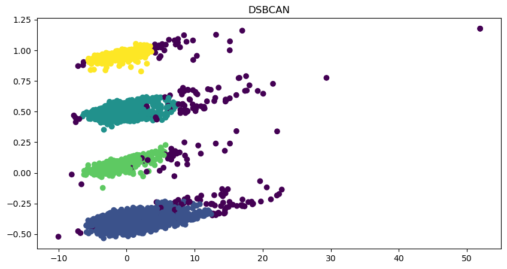

```
[-1  0  1  2  3]
```

```python
dbscan = DBSCAN(eps= 0.82, min_samples= 14).fit(X)
fig, ax = plt.subplots(sharex=True, figsize = (10,5))
plt.scatter(rates_pca[:,0], rates_pca[:,1], c = dbscan.labels_)
plt.title('DSBCAN')
plt.show()
print(np.unique(dbscan.labels_))
```

Se puede ver a continuación la distribución de los cluster's mediante DBSCAN. Se va considerar la clase `-1` corresponde a ruido debido a que no se adaptan a ningún cluster.

```python
np.unique(dbscan.labels_, return_counts = True)
```

```
(array([-1,  0,  1,  2,  3], dtype=int64),
 array([ 224, 2112,  822,  518,  324], dtype=int64))
```

## Metricas de Evaluación

```python
from sklearn.metrics import silhouette_score

print("Dataset X K-Means\t", silhouette_score(data_k_means, kmeans.labels_))
print("Dataset X Ward \t", silhouette_score(X, ward_euclidean.labels_))
print("Dataset X Complete\t", silhouette_score(X, complete_cosine.labels_))
print("Dataset X Average \t", silhouette_score(X, average_cosine.labels_))
print("Dataset X DBSCAN\t", silhouette_score(X, dbscan.labels_ >= 0))
```

```
Dataset X K-Means	 0.45092067945710973
Dataset X Ward 	 0.2783986455924594
Dataset X Complete	 -0.002193212127794123
Dataset X Average 	 0.16915808575224367
Dataset X DBSCAN	 0.5990707234350278
```

## Evaluación de Resultados

Viendo que DBSCAN obtuvo el valor más cercano a 1 de los métodos utilizados se procederá a estudiar este para obtener la respuesta de la pregunta 3, por lo que se concatenan el ID de cada cluster a la tabla con los `dbscan.labels_`:

```python
DBSCAN_results = data_cleaned_sample.copy()
DBSCAN_results['Cluster ID'] = dbscan.labels_
DBSCAN_results.head(2)
```

|  | Name | Album | Artist | Danceability | Duration | Energy | Explicit | Instrumentalness | Liveness | Loudness | Mode | Acousticness | Popularity | Speechiness | Tempo | TimeSignature | Valence | Genres | Cluster ID |
| --- | --- | --- | --- | --- | --- | --- | --- | --- | --- | --- | --- | --- | --- | --- | --- | --- | --- | --- | --- |
| 105914 | True Colors (Glee Cast Version) | Glee: The Music, The Complete Season One | Glee Cast | 0.611 | 214000 | 0.387 | 0 | 0.0 | 0.2130 | -7.949 | 1 | 0.1180 | 36 | 0.0242 | 85.978 | 4 | 0.335 | glee club,hollywood,pop,post-teen pop | 0 |
| 30003 | No Soy El Aire | Habítame Siempre (Bonus Tracks Version) | Thalia | 0.362 | 246413 | 0.596 | 0 | 0.0 | 0.0755 | -7.054 | 0 | 0.0369 | 41 | 0.0338 | 148.471 | 4 | 0.201 | dance pop,latin,latin pop,mexican pop,pop,trop... | 1 |

Se crea un Dataframe para cada las instancias de cada clase.

```python
cluster_0 = DBSCAN_results[DBSCAN_results['Cluster ID'] == 0]
cluster_1 = DBSCAN_results[DBSCAN_results['Cluster ID'] == 1]
cluster_2 = DBSCAN_results[DBSCAN_results['Cluster ID'] == 2]
cluster_3 = DBSCAN_results[DBSCAN_results['Cluster ID'] == 3]
cluster_4 = DBSCAN_results[DBSCAN_results['Cluster ID'] == 4]
cluster_5 = DBSCAN_results[DBSCAN_results['Cluster ID'] == 5]
cluster_6 = DBSCAN_results[DBSCAN_results['Cluster ID'] == 6]
cluster_7 = DBSCAN_results[DBSCAN_results['Cluster ID'] == 7]
```

En este caso dado que el mejor coeficiente de Silloute se obtiene con el modelo de DBSCAN se evaluaran por **inspección** los clusters. La forma de evaluar las diferencias entre los atributos entre los cluster's va a ser tomando muestras aleatorias y coomparar los valores que componen a cada muestra y así evaluar el conjunto donde se destaca más las diferencias númericas.

```python
cluster_0.sample()
```

|  | Name | Album | Artist | Danceability | Duration | Energy | Explicit | Instrumentalness | Liveness | Loudness | Mode | Acousticness | Popularity | Speechiness | Tempo | TimeSignature | Valence | Genres | Cluster ID |
| --- | --- | --- | --- | --- | --- | --- | --- | --- | --- | --- | --- | --- | --- | --- | --- | --- | --- | --- | --- |
| 4770 | Goin' Down South | Burnside On Burnside | R.L. | 0.439 | 344400 | 0.954 | 0 | 0.00349 | 0.718 | -3.241 | 1 | 0.0839 | 2 | 0.0481 | 100.101 | 4 | 0.729 | acoustic blues,blues,country blues,delta blues... | 0 |

```python
cluster_2.sample()
```

|  | Name | Album | Artist | Danceability | Duration | Energy | Explicit | Instrumentalness | Liveness | Loudness | Mode | Acousticness | Popularity | Speechiness | Tempo | TimeSignature | Valence | Genres | Cluster ID |
| --- | --- | --- | --- | --- | --- | --- | --- | --- | --- | --- | --- | --- | --- | --- | --- | --- | --- | --- | --- |
| 14628 | Carter II | Tha Carter II [Deluxe Edition (Explicit)] | Lil' Wayne | 0.511 | 144080 | 0.739 | 1 | 0.0 | 0.153 | -5.333 | 1 | 0.0933 | 0 | 0.286 | 86.925 | 4 | 0.48 | hip hop,new orleans rap,pop,pop rap,rap,trap m... | 2 |

Para evaluar si los cluster logran asociar una tendencia en los atributos a un género o conjunto de géneros, se contabilizaran los generos asociados a cada instancia para todas las instancia de un mismo cluster.

```python
def contarGen(df):
    dicc = {}
    i = 0
    for row, col in df.iterrows():
        if type(col['Genres']) == float:
            continue
        aux = col['Genres'].split(',')
        for k in aux:
            if k in aux:
                dicc[k] = dicc.get(k,0) + 1
            i+=1
    gen = pd.DataFrame([[key, dicc[key]] for key in dicc.keys()], columns=['Genre', 'Frequency'])
    gen1_5 = gen.sort_values(by = ['Frequency'], ascending=False)
    return gen1_5
```

```python
contarGen(cluster_1).head(8)
```

|  | Genre | Frequency |
| --- | --- | --- |
| 0 | dance pop | 217 |
| 4 | pop | 208 |
| 13 | r&b | 142 |
| 16 | urban contemporary | 132 |
| 11 | pop rap | 126 |
| 7 | hip hop | 125 |
| 8 | hip pop | 111 |
| 9 | neo soul | 94 |

```python
contarGen(cluster_2).head(8)
```

|  | Genre | Frequency |
| --- | --- | --- |
| 9 | pop rap | 382 |
| 10 | rap | 367 |
| 18 | hip hop | 320 |
| 11 | southern hip hop | 303 |
| 8 | gangster rap | 276 |
| 12 | trap music | 253 |
| 7 | dirty south rap | 175 |
| 13 | pop | 112 |

```python
contarGen(cluster_5).head(8)
```

|  | Genre | Frequency |
| --- | --- | --- |

Se puede apreciar que orientar nuestro análisis a los generos musicales puede beneficiarnos de muchas maneras debido a que no poseen diferencias muy marcadas a dia de hoy y las canciones en particular poseen muchos géneros lo cual al ser investigado podria entregarnos si la música se volvio repetitiva, lo cual indicaria clusters muy coincidientes entre sí, o que la música esta en auge debido a las nuevas tecnologias y es posible determinar la integridad de los géneros mediante el análisis, por lo cual unos resultados poco claros es justo lo que podriamos estar enfrentando.

Se espera para el Hito 3 explorar variantes de los modelos empleados y de los atributos de la data utilizados para confirmar los resultados actuales o encontrar una combinación que proporciones una clasificación de cluster's relevantes.

## Participación

Para el hito 2 Hernán trabajo en el preprocesamiento de las tablas para la primera pregunta, además de redactar esta pregunta, a su vez trabajo en arreglar algunas combinaciones de tablas para su futura utilización en las preguntas. Alexander se encargó de redactar y preparar la pregunta 2, preprocesando la tabla y aplicando modelos de clasificación los cuales no resultaron en primer momento por lo cual se encargó de reformular el Dataframe para ajustarlo al modelo a utilizar. Gonzalo se encargó de formular la tercera preguntas y su posible resolución proponiendo métodos como clustering y clasificación, ajustar los parámetros de los modelo y evaluar los resultados. Finalmente Ignacio se encargó de realizar los gráficos, configurar los modelos, dendogramas, preprocesar las tablas a utilizar y evaluar los resultados obtenidos de la pregunta 3.